# Problem Set 4

Author

Peng Chen

Published

November 21, 2026

**GitHub repo:** https://github.com/perry-pezza/ec522_ps4_chen

## ARIMA vs. ETS

### 2.1 The Data

```r
library(tidyverse)
library(fpp3)
library(BVAR)
#2.1a
liquor_raw <- read_csv(
  "data/MRTSSM4453USN.csv",
  na = ".",
  col_types = cols(
    observation_date = col_date(format = "%Y-%m-%d"),
    MRTSSM4453USN = col_double()
  )
)

liquor <- liquor_raw |>
  transmute(Month = yearmonth(observation_date), sales = MRTSSM4453USN) |>
  as_tsibble(index = Month) |>
  filter(Month <= yearmonth("2019 Dec"))

has_gaps(liquor)
```

```
# A tibble: 1 × 1
  .gaps
  <lgl>
1 FALSE
```

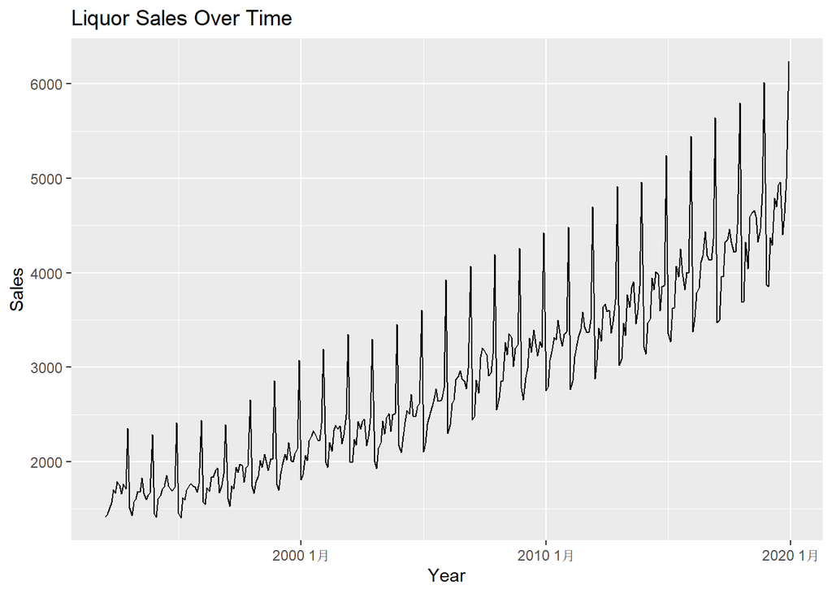

```r
#2.1b
autoplot(liquor, sales) +
  labs(title = "Liquor Sales Over Time",
       x = "Year",
       y = "Sales")
```

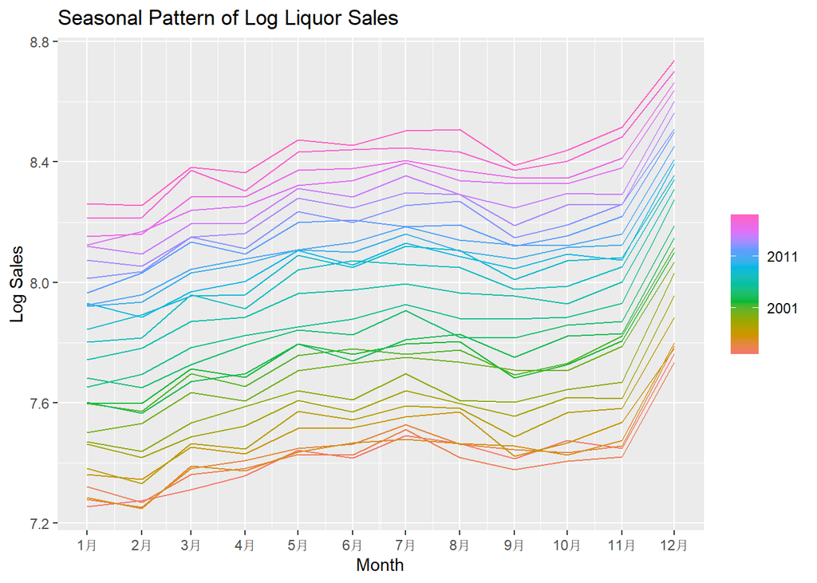

```r
gg_season(liquor, log(sales)) +
  labs(title = "Seasonal Pattern of Log Liquor Sales",
       x = "Month",
       y = "Log Sales")
```

Liquor sales show a clear upward trend over time, with a strong seasonal pattern. Sales are generally highest in December and lower at the beginning of the year. The seasonal fluctuations become larger as the sales level increases, suggesting a multiplicative seasonal pattern. Taking logarithms helps stabilize these fluctuations and makes the seasonal pattern more consistent over time.

### 2.2 Fit Both Models

```r
#2.2a
liquor_fit <- liquor |>
  model(arima = ARIMA(log(sales)),
        ets   = ETS(log(sales)))

liquor_fit |> select(arima) |> report()
```

```
Series: sales
Model: ARIMA(1,0,2)(2,1,1)[12] w/ drift
Transformation: log(sales)

Coefficients:
         ar1      ma1     ma2    sar1     sar2     sma1  constant
      0.8948  -0.7374  0.2477  0.3679  -0.2334  -0.8845    0.0036
s.e.  0.0355   0.0697  0.0623  0.0668   0.0665   0.0468    0.0001

sigma^2 estimated as 0.0005469:  log likelihood=752.43
AIC=-1488.85   AICc=-1488.4   BIC=-1458.61
```

```r
liquor_fit |> select(ets) |> report()
```

```
Series: sales
Model: ETS(A,A,A)
Transformation: log(sales)
  Smoothing parameters:
    alpha = 0.3296099
    beta  = 0.007560263
    gamma = 0.0001765132

  Initial states:
     l[0]         b[0]      s[0]      s[-1]        s[-2]       s[-3]      s[-4]
 7.412219 0.0007608238 0.3263441 0.03153301 -0.004849389 -0.03530501 0.02512163
      s[-5]      s[-6]      s[-7]       s[-8]      s[-9]     s[-10]     s[-11]
 0.05558624 0.01219515 0.02503206 -0.06088935 -0.0607952 -0.1578065 -0.1561667

  sigma^2:  7e-04

      AIC      AICc       BIC
-489.1517 -487.2272 -424.2608
```

The selected ARIMA model is ARIMA(1,0,2)(2,1,1)[12] with drift. It includes seasonal differencing but no regular differencing. The selected ETS model is ETS(A,A,A), with additive error, trend, and seasonality on the log scale.

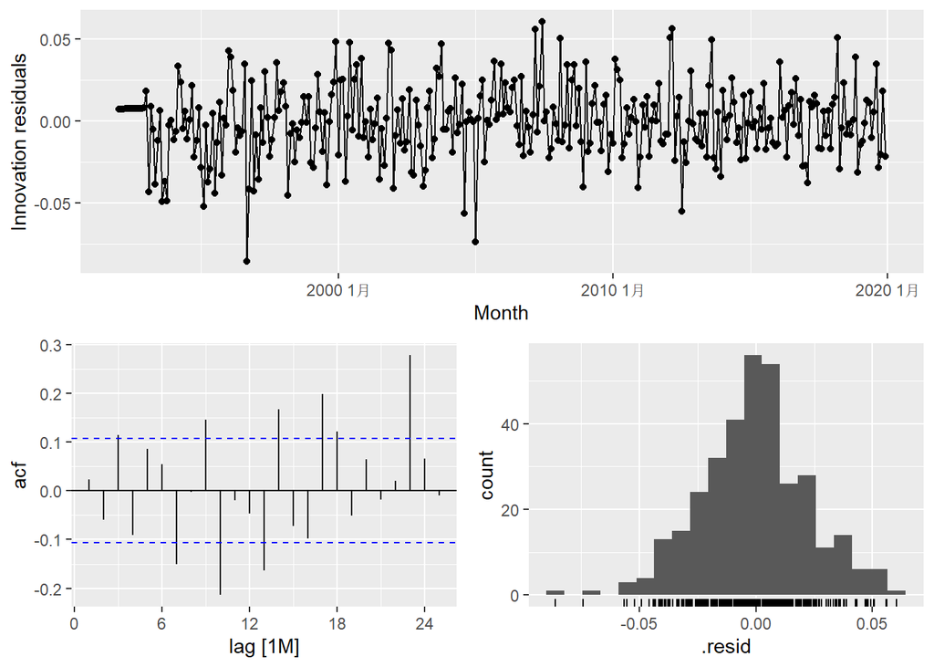

```r
#2.2b
liquor_fit |> select(arima) |> gg_tsresiduals()
```

```r
liquor_fit |>
  select(arima) |>
  augment() |>
  features(.innov, ljung_box, lag = 24, dof = 6)
```

```
# A tibble: 1 × 3
  .model lb_stat lb_pvalue
  <chr>    <dbl>     <dbl>
1 arima     120.         0
```

The Ljung–Box test gives a p-value close to zero, which is below 0.05. Therefore, we reject the null hypothesis of no autocorrelation. The ARIMA residuals are not white noise, suggesting that some temporal dependence remains unexplained by the model.

### 2.3 The Horse Race

```r
#2.3aLoad the previously estimated models
liquor_cv_fit <- readRDS("results/liquor_cv_fit.rds")

# 2.3b
liquor_cv_fc <- liquor_cv_fit |>
  forecast(h = 1)

liquor_cv_fc |>
  accuracy(liquor, measures = list(RMSE = RMSE, MAE = MAE)) |>
  knitr::kable(digits = 2)
```

| .model | .type | RMSE | MAE |
| --- | --- | --- | --- |
| arima | Test | 81.43 | 65.65 |
| ets | Test | 94.35 | 72.31 |
| snaive | Test | 161.26 | 136.63 |

The ARIMA model performs best, with the lowest RMSE (81.43) and MAE (65.65). ETS ranks second, with an RMSE of 94.35 and an MAE of 72.31. SNAIVE performs worst, with an RMSE of 161.26 and an MAE of 136.63. Both accuracy measures give the same ranking: ARIMA, ETS, and SNAIVE. This suggests that ARIMA provides the most accurate one-step-ahead forecasts among the three models in this exercise.

### 2.4 Differences Significant

```r
#2.4
liquor_errs <- liquor_cv_fc |>
  as_tibble() |>
  left_join(as_tibble(liquor) |> select(Month, actual = sales),
            by = "Month") |>
  mutate(e = actual - .mean) |>
  select(Month, .model, e) |>
  pivot_wider(names_from = .model, values_from = e)

forecast::dm.test(liquor_errs$arima, liquor_errs$ets, h = 1, power = 2)
```

```
    Diebold-Mariano Test

data:  liquor_errs$arimaliquor_errs$ets
DM = -2.9062, Forecast horizon = 1, Loss function power = 2, p-value =
0.004042
alternative hypothesis: two.sided
```

```r
forecast::dm.test(liquor_errs$arima, liquor_errs$snaive, h = 1,power = 2)
```

```
    Diebold-Mariano Test

data:  liquor_errs$arimaliquor_errs$snaive
DM = -10.755, Forecast horizon = 1, Loss function power = 2, p-value <
2.2e-16
alternative hypothesis: two.sided
```

The Diebold-Mariano tests show that ARIMA performs significantly better than both ETS and SNAIVE. The p-value is 0.0040 for ARIMA versus ETS and less than 2.2e-16 for ARIMA versus SNAIVE. Both are below 0.05, so we reject the null hypothesis of equal predictive accuracy. Combined with the lower RMSE and MAE values in Section 2.3, these results suggest that ARIMA is the best forecasting model among the three.

## Forecast Combination

```r
#part 3a
liquor_combo_fc <- liquor_cv_fit |>
  mutate(combo = (arima + ets) / 2) |>
  forecast(h = 1)

liquor_combo_fc |>
  accuracy(liquor, measures = list(RMSE = RMSE, MAE = MAE))|> knitr::kable(digits = 2)
```

| .model | .type | RMSE | MAE |
| --- | --- | --- | --- |
| arima | Test | 81.43 | 65.65 |
| combo | Test | 85.19 | 66.77 |
| ets | Test | 94.35 | 72.31 |
| snaive | Test | 161.26 | 136.63 |

The equal-weight combination has an RMSE of 85.19 and an MAE of 66.77. It performs better than ETS (RMSE = 94.35, MAE = 72.31), but worse than ARIMA (RMSE = 81.43, MAE = 65.65). Therefore, ARIMA remains the best-performing model.

```r
#part 3b
cor(liquor_errs$arima, liquor_errs$ets)
```

```
[1] 0.8782931
```

The correlation between ARIMA and ETS forecast errors is 0.8783, indicating that their errors are highly correlated. The DM test in Section 2.4 also shows that ARIMA significantly outperforms ETS (p = 0.0040). Therefore, combining the two models provides limited diversification benefits and does not improve upon ARIMA alone.

## VAR vs. a BVAR

### 4.1 The Data

```r
#4.1a
qd_raw <- read_csv("data/fredqd_2026-09.csv", show_col_types = FALSE) |>
  slice(-(1:2))
```

```r
#4.1b
growth <- function(x) 100 * difference(log(x))

qd <- qd_raw |>
  mutate(date = as.Date(sasdate, "%m/%d/%Y")) |>
  transmute(date,
            gdp    = growth(GDPC1),     # real GDP
            cons   = growth(PCECC96),   # real consumption
            inv    = growth(GPDIC1),    # real investment
            emp    = growth(PAYEMS),    # payroll employment
            infl   = growth(GDPCTPI),   # GDP price index
            unrate = difference(UNRATE),     # unemployment rate
            ffr    = difference(FEDFUNDS),   # federal funds rate
            gs10   = difference(GS10)) |>    # 10-year Treasury yield
  filter(date >= as.Date("1960-03-01"), date <= as.Date("2019-12-01"))

y <- qd |> select(-date) |> as.matrix()

nrow(y)
```

```
[1] 240
```

```r
head(y)
```

```
            gdp        cons         inv        emp      infl  unrate     ffr
[1,]  2.2237184  0.95210372   9.5789412  1.2792747 0.1884647 -0.4667 -0.0567
[2,] -0.5398116  1.25352433  -9.7837838  0.2416811 0.3564604  0.1000 -0.2366
[3,]  0.4887350 -0.40052924  -0.2544693 -0.5091283 0.4325238  0.3000 -0.7600
[4,] -1.2914344  0.12942668 -11.7409889 -0.5914079 0.4370749  0.7334 -0.6400
[5,]  0.6727499 -0.03714266   2.5619282 -0.5862248 0.1153772  0.5333 -0.2934
[6,]  1.6836022  1.47721924   6.7723497  0.3046958 0.1983937  0.2000 -0.2700
        gs10
[1,] -0.0966
[2,] -0.2267
[3,] -0.4267
[4,]  0.0534
[5,] -0.1000
[6,]  0.0033
```

The dataset contains 240 quarterly observations and eight macroeconomic variables, covering the period from 1960 Q1 to 2019 Q4.

```r
#4.1c
N <- nrow(y)
origins <- 120:(N - 1)
actual <- y[121:N, ]
```

I produce 120 one-quarter-ahead forecasts for each variable using an expanding window. The first forecast is for 1990 Q1, based on the initial training sample from 1960 Q1 to 1989 Q4. The last forecast is for 2019 Q4.

### 4.2 OLS VARs

```r
#4.2 OLS VARs
var_ols_fc <- function(z, p) {
  e <- embed(z, p + 1)            # columns: y_t, then its lags 1 to p
  M <- ncol(z)                    # number of variables
  B <- coef(lm(e[, 1:M] ~ e[, -(1:M)]))
  x <- c(1, t(z[nrow(z):(nrow(z) - p + 1), ]))   # constant, latest p lags
  x %*% B
}

fc_var1 <- NULL
fc_var4 <- NULL
for (T in origins) {
  fc_var1 <- rbind(fc_var1, var_ols_fc(y[1:T, ], 1))
  fc_var4 <- rbind(fc_var4, var_ols_fc(y[1:T, ], 4))
}

rmse_by_var <- function(f) sqrt(colMeans((actual - f)^2))

rmse_by_var(fc_var1)
```

```
      gdp      cons       inv       emp      infl    unrate       ffr      gs10
0.5130384 0.4598547 2.4927057 0.1956584 0.2084055 0.1988068 0.3902989 0.3610310
```

```r
rmse_by_var(fc_var4)
```

```
      gdp      cons       inv       emp      infl    unrate       ffr      gs10
0.5693241 0.5268484 2.5212629 0.2277561 0.2069608 0.2153966 0.4973504 0.3789663
```

VAR(1) performs better than VAR(4) for 7 out of 8 variables based on RMSE. VAR(4) performs slightly better only for inflation. Although VAR(4) includes VAR(1) as a special case, it estimates more parameters, which can lead to overfitting and greater estimation uncertainty. Therefore, the simpler VAR(1) can produce more accurate out-of-sample forecasts.

### 4.3 A BVAR

```r
var_results <- readRDS("results/var_results.rds")
var_results |> knitr::kable(digits = 3)
```

| Variable | VAR(1) | VAR(4) | BVAR(4), lambda = 0.3 | BVAR(4), lambda = 0.05 |
| --- | --- | --- | --- | --- |
| gdp | 0.513 | 0.569 | 0.539 | 0.567 |
| cons | 0.460 | 0.527 | 0.486 | 0.495 |
| inv | 2.493 | 2.521 | 2.385 | 2.698 |
| emp | 0.196 | 0.228 | 0.211 | 0.315 |
| infl | 0.208 | 0.207 | 0.197 | 0.330 |
| unrate | 0.199 | 0.215 | 0.203 | 0.216 |
| ffr | 0.390 | 0.497 | 0.414 | 0.358 |
| gs10 | 0.361 | 0.379 | 0.359 | 0.362 |

When λ decreases to 0.05, shrinkage becomes stronger, but forecast accuracy generally worsens. This suggests that excessive shrinkage can remove useful information. Finally, choosing the best model using this same RMSE table may lead to an overly optimistic estimate of future forecasting performance, because the evaluation data are also being used for model selection. A separate test sample would provide a fairer assessment.

```r
#4.3c
fc_bvar_03 <- readRDS("results/fc_bvar_03.rds")

e_var4 <- actual[, "gdp"] - fc_var4[, 1]
e_bvar <- actual[, "gdp"] - fc_bvar_03[, 1]

forecast::dm.test(e_var4, e_bvar, h = 1, power = 2)
```

```
    Diebold-Mariano Test

data:  e_var4e_bvar
DM = 2.1366, Forecast horizon = 1, Loss function power = 2, p-value =
0.03468
alternative hypothesis: two.sided
```

```r
e_var4_inv <- actual[, "inv"] - fc_var4[, 3]
e_bvar_inv <- actual[, "inv"] - fc_bvar_03[, 3]

forecast::dm.test(e_var4_inv, e_bvar_inv, h = 1, power = 2)
```

```
    Diebold-Mariano Test

data:  e_var4_inve_bvar_inv
DM = 1.6265, Forecast horizon = 1, Loss function power = 2, p-value =
0.1065
alternative hypothesis: two.sided
```

The Diebold–Mariano test for GDP growth gives a p-value of 0.0347, indicating that BVAR(4) with λ = 0.3 forecasts significantly better than VAR(4) at the 5% level. For investment, the p-value is 0.1065, so the difference is not statistically significant, even though BVAR has a lower RMSE.

These results suggest that the improvements in RMSE observed in Part 4.3b are not necessarily statistically significant. Therefore, we should consider both forecast accuracy measures and statistical tests when comparing models.

## Factor Model

### 5.1 The Data

```r
md_raw <- read_csv("data/fredmd_2026-09.csv", show_col_types = FALSE)
tcode <- unlist(md_raw[1, -1])
md <- md_raw[-1, ] |> mutate(date = as.Date(sasdate, "%m/%d/%Y"))

transform_series <- function(x, code) {
  d <- function(v) c(NA, diff(v))
  switch(as.character(code),
         "1" = x,                      # level
         "2" = d(x),                   # first difference
         "3" = d(d(x)),                # second difference
         "4" = log(x),                 # log
         "5" = 100 * d(log(x)),        # growth rate
         "6" = 100 * d(d(log(x))),     # change in the growth rate
         "7" = d(x / dplyr::lag(x) - 1))
}
```

```r
#5.1b
fm <- map2_dfc(md[names(tcode)], tcode, transform_series) |>
  mutate(date = md$date, .before = 1) |>
  filter(date >= as.Date("1960-03-01"), date <= as.Date("2019-12-01"))

fm <- fm[, colSums(is.na(fm)) == 0]

dim(fm)
```

```
[1] 718 122
```

```r
#5.1c
tcode[c("INDPRO", "PAYEMS", "CPIAUCSL", "FEDFUNDS")]
```

```
  INDPRO   PAYEMS CPIAUCSL FEDFUNDS
       5        5        6        2
```

After applying the recommended transformations and removing variables with missing observations, the dataset contains 718 monthly observations and 121 economic series, excluding the date column.

### 5.2 Estimate the Factors

```r
#5.2a

Z <- fm |> select(-date) |> as.matrix()
pc <- prcomp(scale(Z))
summary(pc)$importance[, 1:5]
```

```
                            PC1      PC2      PC3      PC4      PC5
Standard deviation     4.258002 2.993839 2.923106 2.597224 2.295261
Proportion of Variance 0.149840 0.074070 0.070620 0.055750 0.043540
Cumulative Proportion  0.149840 0.223910 0.294530 0.350280 0.393820
```

The first three principal components explain approximately 29.45% of the total variation across the 121 economic series.

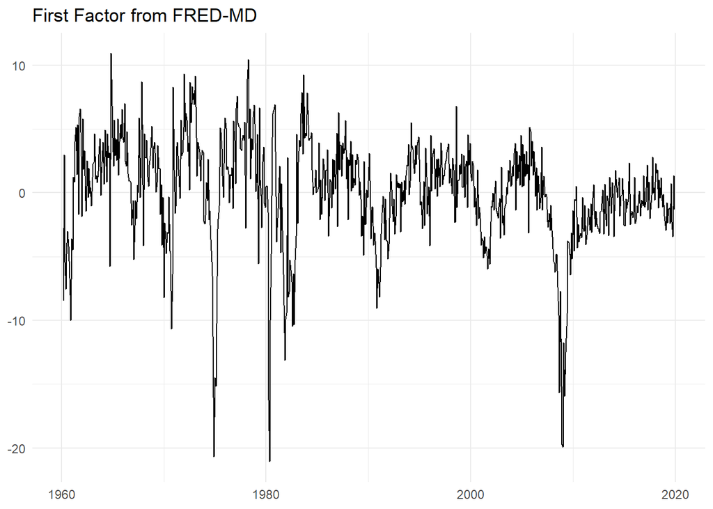

```r
#5.2b
F1 <- pc$x[, 1] * sign(cor(pc$x[, 1], fm$INDPRO))

tibble(date = fm$date, F1 = F1) |>
  ggplot(aes(date, F1)) +
  geom_line() +
  labs(title = "First Factor from FRED-MD", x = NULL, y = NULL) +
  theme_minimal()
```

```r
#5.2c
sort(abs(cor(pc$x[, 1], Z))[1, ], decreasing = TRUE)[1:8]
```

```
   PAYEMS IPMANSICS    USGOOD    INDPRO    MANEMP   IPFPNSS    CUMFNS   DMANEMP
0.8415788 0.8404473 0.8390159 0.8219976 0.8028499 0.7903078 0.7778686 0.7768615
```

```r
sort(abs(cor(pc$x[, 2], Z))[1, ], decreasing = TRUE)[1:8]
```

```
    CUSR0000SAC DNDGRG3M086SBEA   CUSR0000SA0L2        CPIAUCSL   CUSR0000SA0L5
      0.7468587       0.7391330       0.7279202       0.7198020       0.7020307
       CPITRNSL           PCEPI        CPIULFSL
      0.6806883       0.6795890       0.6570361
```

The first factor appears to capture overall economic activity, as it is strongly correlated with employment, industrial production, and manufacturing indicators. The plot also shows sharp declines during major economic downturns, particularly the 2008–2009 financial crisis.

The second factor appears to capture inflation and price movements, since its strongest correlations are with consumer price indices and other price-related variables.

###5.3 Replicate the Horse Race from Class

```r
ip <- fm$INDPRO
n <- nrow(Z)
init <- which(fm$date == as.Date("1989-12-01"))

e_ar <- NULL
e_fa <- NULL
for (T in init:(n - 1)) {
  F_T <- prcomp(scale(Z[1:T, ]))$x[, 1:3]         # factors using data through T
  d <- data.frame(y_next = ip[2:T], y = ip[1:(T - 1)], F_T[1:(T - 1), ])
  new <- data.frame(y = ip[T], t(F_T[T, ]))
  e_ar <- c(e_ar, ip[T + 1] - predict(lm(y_next ~ y, d), new))
  e_fa <- c(e_fa, ip[T + 1] - predict(lm(y_next ~ ., d), new))
}

c(RMSE_AR = sqrt(mean(e_ar^2)), RMSE_FA = sqrt(mean(e_fa^2)))
```

```
  RMSE_AR   RMSE_FA
0.6168431 0.5887272
```

The results match those from class. The AR(1) model has an RMSE of 0.617, while the AR(1) model with three factors has a lower RMSE of 0.589, indicating better forecasting performance.

Estimating the factors using the full sample would introduce information leakage because future observations would be used to construct factors for earlier forecasts. This would make the out-of-sample evaluation unfair and potentially overestimate forecasting accuracy.

###5.4 A Direct Forecast of Inflation

```r
#5.4

direct_race <- function(series, h = 12, r = 3) {
lv <- md |>
  mutate(log_x = log(.data[[series]]),
         g = 100 * (log_x - lag(log_x))) |>
  filter(date >= as.Date("1960-03-01"), date <= as.Date("2019-12-01"))
yh <- 100 * (lead(lv$log_x, h) - lv$log_x)      # growth over the next h months
g  <- lv$g                                      # growth over the latest month

e_ar <- NULL
e_fa <- NULL
for (T in init:(n - h)) {
  F_T <- prcomp(scale(Z[1:T, ]))$x[, 1:r, drop = FALSE]
  i <- 1:(T - h)
  d <- data.frame(yh = yh[i], g = g[i], F_T[i, , drop = FALSE])
  new <- data.frame(g = g[T], F_T[T, , drop = FALSE])
  e_ar <- c(e_ar, yh[T] - predict(lm(yh ~ g, d), new))
  e_fa <- c(e_fa, yh[T] - predict(lm(yh ~ ., d), new))
}
tibble(series, forecasts = length(e_ar),
       RMSE_AR = sqrt(mean(e_ar^2)), RMSE_FA = sqrt(mean(e_fa^2)),
       MAE_AR = mean(abs(e_ar)), MAE_FA = mean(abs(e_fa)),
       DM_pvalue = forecast::dm.test(e_ar, e_fa, h = h, power = 2,
                                     varestimator = "bartlett")$p.value)
}

direct_race("CPIAUCSL")
```

```
# A tibble: 1 × 7
  series   forecasts RMSE_AR RMSE_FA MAE_AR MAE_FA DM_pvalue
  <chr>        <int>   <dbl>   <dbl>  <dbl>  <dbl>     <dbl>
1 CPIAUCSL       349    2.11    1.89   1.58   1.35  0.000443
```

Adding three factors improves the forecast of 12-month CPI inflation. The RMSE decreases from 2.11 to 1.89, a reduction of approximately 10.4%. The MAE also decreases from 1.58 to 1.35.

The Diebold–Mariano test gives a p-value of 0.000443, which is below 0.05. Therefore, we reject the null hypothesis of equal predictive accuracy. The improvement from adding the factors is statistically significant.

## Reflection

Throughout this problem set, I learned that more complicated models do not necessarily produce more accurate forecasts. Comparing ARIMA and ETS showed me the importance of evaluating models using out-of-sample accuracy rather than relying only on how well they fit the data. Forecast combinations showed that simple equal weights can be useful because we do not always know which individual model will perform best. In the VAR and BVAR comparisons, I found that adding more lags can lead to overfitting, while shrinkage can help reduce estimation uncertainty. The factor models also showed that we can use information from many economic variables without including all of them separately in a forecasting model. Overall, I realized that shrinkage, equal weights, and factors share a similar idea: reducing the need to estimate too many uncertain parameters, while balancing simplicity with useful information.